# Ejemplo de solución ejercicio prático N°7

## Pregunta 2

La memorista también sospecha que, al comparar las mismas instancias con 70 a 85 nodos, las mejores soluciones encontradas por las versiones B y C tienen rendimientos distintos. ¿Estará en lo cierto?

Para responder, filtren los datos para tener las instancias que tengan de 70 a 85 nodos y seleccionen las columnas con el mejor rendimiento de las versiones B y C en formato ancho. Usando como semilla el valor 117, obtengan una muestra aleatoria de 24 instancias. Lleven los datos a formato largo y utilicen una prueba no paramétrica apropiada para analizar las muestras obtenidas.

Obtenemos la muestra de datos en formato ancho. Como tenemos que comparar los resultados obtenidos por los algoritmos con *las mismas instancias*, debemos obtener una muestra apareada de 24 observaciones.

```r
set.seed(117)
dw2 <- datos %>%
  filter(n.nodos >= 70 & n.nodos <= 85) %>%
  select(instancia, mejor.B, mejor.C) %>%
  sample_n(24)
```

Llevamos los datos a formato largo

```r
dl2 <- dw2 %>%
  pivot_longer(
    cols = c("mejor.B", "mejor.C"),
    names_to = "algoritmo",
    values_to = "resultado"
  )
dl2[["instancia"]] <- factor(dl2[["instancia"]])
dl2[["algoritmo"]] <- factor(dl2[["algoritmo"]])
```

Revisemos los datos con un diagrama de cajas

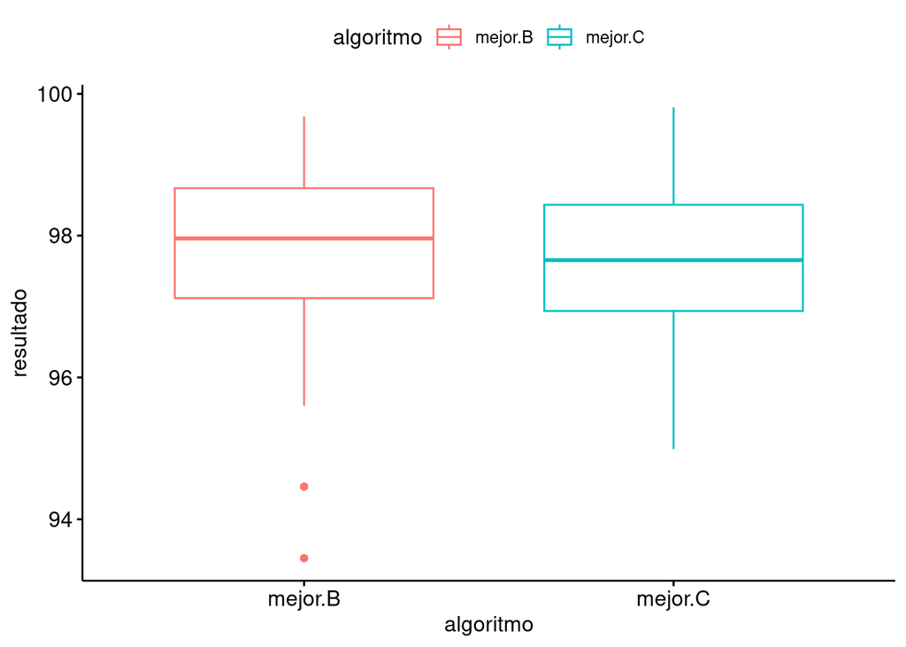

```r
p2 <- ggboxplot(
  data = dl2,
  x = "algoritmo", y = "resultado",
  xlab = "algoritmo",
  color = "algoritmo"
)
print(p2)
```

Vemos que los datos para el algoritmo B presentan una leve asimetría y la presencia de valores atípicos. Sería prudente utilizar una prueba no paramétrica para el análisis, como alternativa a una prueba T de Student para muestras apareadas, que en este caso correspondería a una **prueba de rangos con signo de Wilcoxon**, con las siguientes hipótesis:

H$_0$: no hay diferencia en las mejores soluciones encontradas por las versiones B y C del algoritmo en las mismas instancias con 70 a 85 nodos (se distribuyen de igual forma).

H$_A$: sí hay diferencias en las mejores soluciones obtenidas por ambas versiones del algoritmo en las mismas instancias con 70 a 85 nodos (distribuciones distintas).

Verifiquemos las condiciones:

1. Los pares de observaciones son independientes. Efectivamente, si el experimento fue realizado correctamente por la memorista, cómo se desempeña un algoritmo no debería tener influencia en cómo rinde el segundo.
2. La escala de medición empleada para ambas muestras debe ser a lo menos ordinal. Valores porcentuales cumplen esta condición, pues podemos compararlos y ordenarlos.
3. La escala de medición empleada para las observaciones es intrínsecamente continua. Al tratarse de valores porcentuales, en *teoría* estas mediciones podrían tener un número indeterminado de decimales, por lo que cumpliría con esta condición.

Procedamos con la prueba no paramétrica, ya que se cumplen todas las condiciones.

```r
prueba2 <- wilcox.test(
  x = dw2[["mejor.B"]],
  y = dw2[["mejor.C"]],
  paired = TRUE
)
cat("Prueba de rangos con signo de Wilcoxon\n")
```

```
## Prueba de rangos con signo de Wilcoxon
```

```r
print(prueba2)
```

```
##
##  Wilcoxon signed rank exact test
##
## data:  dw2[["mejor.B"]] and dw2[["mejor.C"]]
## V = 167, p-value = 0.6431
## alternative hypothesis: true location shift is not equal to 0
```

El resultado de la prueba indica que no hay suficiente evidencia ($V=167, p = 0,\!643$) para descartar la hipótesis nula en favor de la alternativa. Así, pareciera que el algoritmo B consigue resultados similares a los que se obtienen con el algoritmo C en las mismas instancias con 70 a 85 nodos.

## Pregunta 3

La memorista además cree que hay diferencias significativas en el tiempo de ejecución entre las versiones del algoritmo cuando las instancias de prueba tienen 100 o más nodos. ¿Los datos respaldan la intuición de la memorista?

Para responder, filtren los datos para tener las instancias con 100 o más nodos y seleccionen las columnas con los tiempos de ejecución registrados (en formato ancho). Usando como semilla el valor 33, obtengan muestras aleatorias independientes de 12, 13 y 14 tiempos registrados por las versiones A, B y C, respectivamente. Lleven los datos a formato largo y utilicen una prueba no paramétrica para analizar las muestras obtenidas.

Primero, filtramos para quedarnos con las instancias que nos interesan y quitar las columnas que no necesitamos.

```r
dw3 <- datos %>%
  filter(n.nodos >= 100) %>%
  select(instancia, tiempo.A, tiempo.B, tiempo.C)
```

Ahora tomamos la muestra solicitada.

```r
nA <- 12; nB <- 13; nC <- 14
nI <- nA + nB + nC
```

Es importante que lo hagamos con una sola llamada a la función `sample()`, para evitar que los algoritmos compartan alguna instancia, asegurando así muestras independientes.

```r
set.seed(33)
i <- sample(1:nrow(dw3), nI)
seleccion <- dw3[i, ]
tiempo.A <- seleccion[["tiempo.A"]][1:nA]
tiempo.B <- seleccion[["tiempo.B"]][(nA+1):(nA+nB)]
tiempo.C <- seleccion[["tiempo.C"]][(nA+nB+1):nI]
```

Creamos una versión larga de los datos.

```r
dl3 <- data.frame(
  instancia = seleccion[["instancia"]],
  algoritmo = c(rep("A", nA), rep("B", nB), rep("C", nC)),
  tiempo = c(tiempo.A, tiempo.B, tiempo.C)
)
dl3[["instancia"]] <- factor(dl3[["instancia"]])
dl3[["algoritmo"]] <- factor(dl3[["algoritmo"]])
```

Puesto que cada muestra contiene instancias de prueba distintas, la primera alternativa sería usar ANOVA de una vía para muestras independientes para este análisis. Esta prueba permitiría determinar si la memorista tiene o no razón en pensar que existen diferencias significativas en los tiempos medios de ejecución de los algoritmos.

Verificamos las condiciones:

1. Existe independencia entre las muestras, pues no hay elementos en común y el tiempo que tarda un algoritmo en alguna de las instancias escogida no debería influir en el tiempo que tarda otro algoritmo en otra instancia.
2. También se cumple que la variable dependiente tiene una escala de intervalos iguales, pues es una medición física (tiempo).
3. Veamos si se cumple con las condiciones de normalidad y homocedasticidad por medio de histogramas.

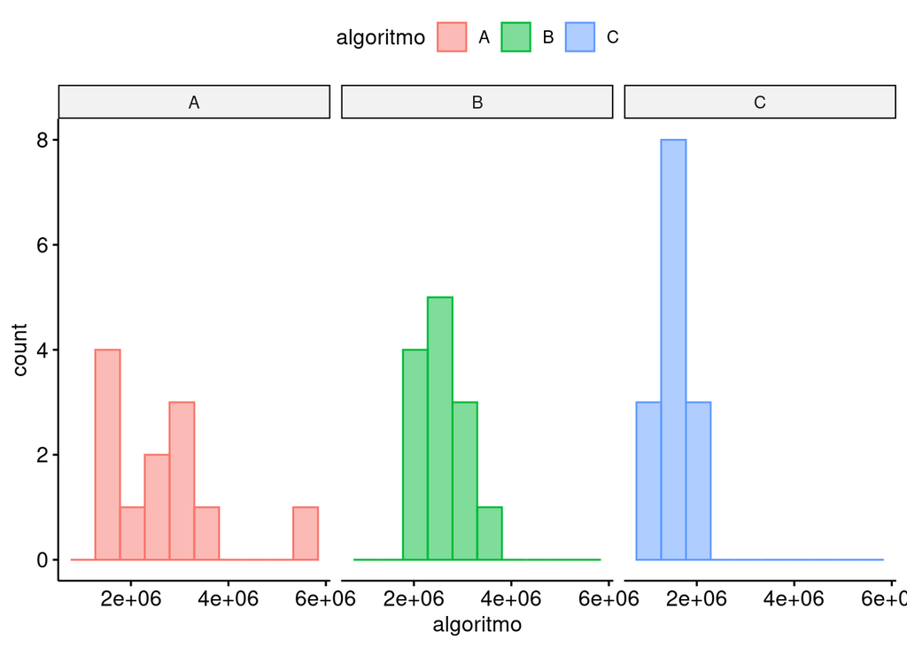

```r
p3 <- gghistogram(
  dl3,
  x = "tiempo",
  xlab = "algoritmo",
  color = "algoritmo", fill = "algoritmo",
  bins = 10
)
p3 <- p3 + facet_grid(~ algoritmo)
print(p3)
```

Podemos ver que las muestras no siguen un comportamiento aproximadamente normal, por lo que no podríamos suponer razonablemente que las poblaciones de donde provienen sí tengan dicha distribución.

Como el problema no parece requerir un valor de las medias estudiadas, sería conveniente bajar las exigencias y optar por una prueba no paramétrica, como se nos indica en el enunciado. En este caso, correspondería una prueba de **Kruskal-Wallis**.

Mirando el gráfico, no podríamos suponer tampoco que las formas de las distribuciones subyacentes sean iguales, por lo que las hipótesis no podrían referirse a medianas. Así, las hipótesis no paramétricas a contrastar serían:

H$_0$: Los tiempos promedios que tardan los algoritmos en resolver las instancias con 100 o más nodos son similares.

H$_A$: al menos uno de los algoritmos exhibe tiempos promedios significativamente distintos a uno de los otros dos algoritmos para resolver las instancias con 100 o más nodos.

Verifiquemos las condiciones:

1. Ya sabemos que existe independencia ente las observaciones.
2. También se verifica que la variable independiente tiene más de dos niveles (algoritmos A, B y C).
3. Por último, la escala de la variable dependiente debe ser al menos ordinal, y sabemos que las mediciones físicas cumplen de sobra con tal condición.

Aplicamos la prueba, con el nivel de significación más común.

```r
alfa <- 0.05
prueba3 <- kruskal.test(tiempo ~ algoritmo, data = dl3)
print(prueba3)
```

```
##
##  Kruskal-Wallis rank sum test
##
## data:  tiempo by algoritmo
## Kruskal-Wallis chi-squared = 19.802, df = 2, p-value = 5.012e-05
```

La prueba indica que hay suficiente evidencia para rechazar H0 en favor de HA ($\chi^2=19,\!8;\; p < 0,\!001$). En consecuencia, podemos concluir con 95% de confianza que los algoritmos difieren significativamente en el tiempo que tardan en resolver las instancias del problema del vendedor viajero con 100 o más nodos.

Como la prueba ómnibus de Kruskal-Wallis detecta diferencias, debemos hacer ahora un **procedimiento post-hoc**. Para ello usaremos múltiples pruebas de Wilcoxon-Mann-Whitney entre pares de grupos, aplicando el ajuste de Benjamini & Hochberg (1995) por tener mayor poder estadístico que varios otros métodos.

```r
posthoc1 <- pairwise.wilcox.test(
  dl3[["tiempo"]],
  dl3[["algoritmo"]],
  p.adjust.method = "BH",
  paired = FALSE
)
print(posthoc1)
```

```
##
##  Pairwise comparisons using Wilcoxon rank sum exact test
##
## data:  dl3[["tiempo"]] and dl3[["algoritmo"]]
##
##   A       B
## B 0.64951 -
## C 0.00037 1.3e-05
##
## P value adjustment method: BH
```

El procedimiento post-hoc no encuentra diferencias significativas entre los algoritmos A y B ($p=0,\!650$), pero estos dos algoritmos parecen tardar, en promedio, significativamente más que el algoritmo C ($p<0,\!001$) en resolver las instancias del problema del vendedor viajero con 100 o más nodos.

## Pregunta 4

La memorista también intuye que, al comparar las mismas instancias de prueba con 100 o más nodos, las mejores soluciones encontradas por las diferentes versiones del algoritmo tienen rendimientos distintos. ¿Estará en lo cierto?

Para responder, filtren los datos para tener las instancias con 100 o más nodos y seleccionen las columnas con los mejores rendimientos registrados. Usando como semilla el valor 33, obtengan una muestra aleatoria de 26 instancias. Lleven los datos a formato largo y utilicen una prueba no paramétrica apropiada para analizar los datos obtenidos.

Obtenemos la muestra de datos en formato ancho. Como tenemos que comparar los resultados obtenidos por los algoritmos con *las mismas instancias*, debemos obtener una muestra apareada de 26 observaciones.

```r
nD <- 26
set.seed(33)
dw4 <- datos %>%
  filter(n.nodos >= 100) %>%
  select(instancia, mejor.A, mejor.B, mejor.C) %>%
  sample_n(nD)
```

Llevamos los datos a formato largo

```r
dl4 <- dw4 %>%
  pivot_longer(
    cols = c("mejor.A", "mejor.B", "mejor.C"),
    names_to = "algoritmo",
    values_to = "resultado"
  )
dl4[["instancia"]] <- factor(dl4[["instancia"]])
dl4[["algoritmo"]] <- factor(dl4[["algoritmo"]])
```

Puesto que cada muestra contiene la calidad de la solución obtenida por cada algoritmo al resolver las mismas instancias de prueba, correspondería usar **ANOVA de una vía para medidas repetidas**, que permitiría determinar si la memorista tiene o no razón en pensar que existen diferencias significativas entre los diferentes algoritmos.

Revisemos los datos con un diagrama de cajas.

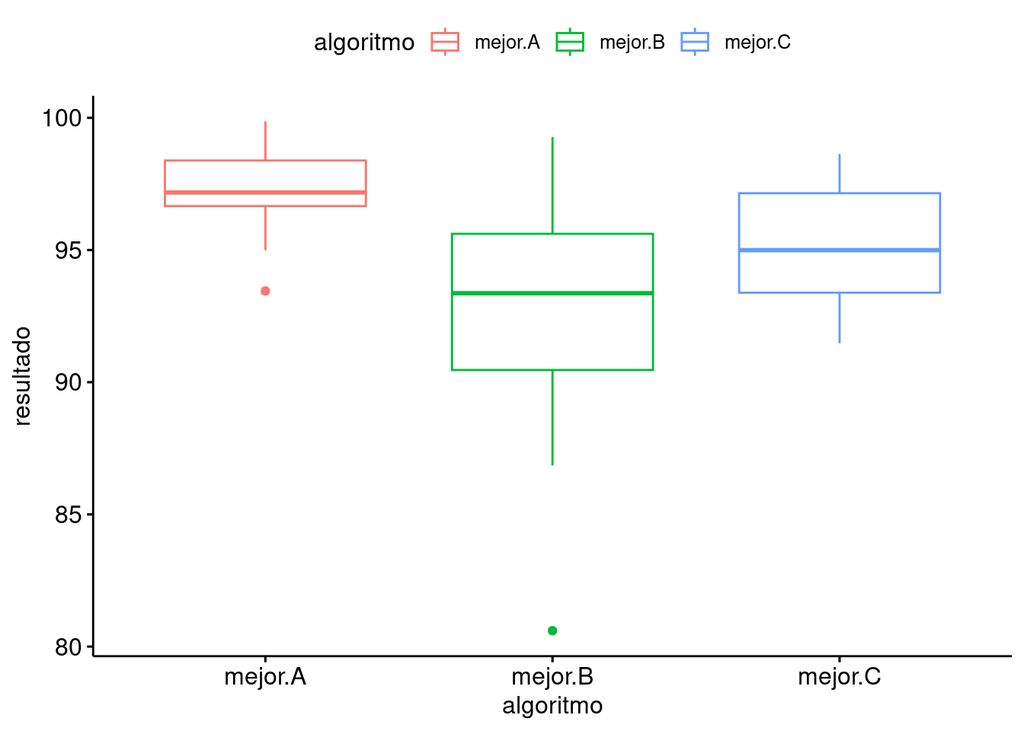

```r
p4 <- ggboxplot(
  dl4,
  x = "algoritmo", y = "resultado",
  xlab = "algoritmo",
  color = "algoritmo"
)
print(p4)
```

Vemos que existe algunos valores atípicos en los datos, además de ciertas asimetrías. Luego, preferimos usar una prueba no paramétrica, como nos instruye el enunciado. Al tratarse de medidas repetidas y más de dos grupos, corresponde usar la **prueba de Friedman**.

Verificamos las condiciones:

1. La variable independiente es categórica y tiene a lo menos tres niveles: `mejor.A`, `mejor.B`y `mejor.C`.
2. Las tripletas de observaciones son independientes pues, si el experimento fue realizado correctamente, el desempeño de un algoritmo no debería tener influencia en el rendimiento que alcancen los otros dos.
3. La escala de la variable dependiente es a lo menos ordinal, pues valores porcentuales se pueden comparar y ordenar.

En consecuencia, se cumplen las condiciones para aplicar la prueba de Friedman, con las siguientes hipótesis no paramétricas:

H$_0$: la calidad de las mejores soluciones conseguidas para las mismas instancias de prueba con 100 o más nodos por los tres algoritmos se distribuyen de forma similar.

H$_A$: al menos uno de los algoritmos entrega mejores soluciones con calidad significativamente distinta que los otros dos al resolver las mismas instancias del problema del vendedor viajero con 100 o más nodos.

Aplicamos la prueba con un nivel de significación exigente por la presencia de valores atípicos ($\alpha=0,\!01$.

```r
prueba4 <- friedman.test(
  resultado ~ algoritmo | instancia,
  data = dl4
)
print(prueba4)
```

```
##
##  Friedman rank sum test
##
## data:  resultado and algoritmo and instancia
## Friedman chi-squared = 21.689, df = 2, p-value = 1.951e-05
```

La prueba indica que hay suficiente evidencia ($\chi^2=21,\!7;\; p < 0,\!001$) para rechazar la hipótesis nula en favor de la alternativa. En consecuencia, podemos concluir con 99% de confianza que al menos uno de los algoritmo tiene un rendimiento distinto a alguno de los otros o a ambos.

Puesto que la prueba ómnibus (de Friedman) detecta diferencias, debemos hacer ahora un procedimiento post-hoc usando múltiples pruebas de rangos con signo de Wilcoxon entre pares de grupos y, al igual que en la pregunta anterior, aplicando el ajuste de Benjamini & Hochberg (1995).

```r
posthoc2 <- pairwise.wilcox.test(
  dl4[["resultado"]],
  dl4[["algoritmo"]],
  p.adjust.method = "BH",
  paired = TRUE
)
```

```
## Warning in wilcox.test.default(xi, xj, paired = paired, ...): cannot compute
## exact p-value with zeroes
```

```r
print(posthoc2)
```

```
##
##  Pairwise comparisons using Wilcoxon signed rank exact test
##
## data:  dl4[["resultado"]] and dl4[["algoritmo"]]
##
##         mejor.A mejor.B
## mejor.B 2.2e-06 -
## mejor.C 0.0025  0.0382
##
## P value adjustment method: BH
```

Por ahora vamos a ignorar el warning que nos da la función, puesto que sabemos que si hay empates, el algoritmo interno de esta prueba los descarta antes del cálculo de los rangos (rankings). Si fuéramos muy rigorosos, deberíamos revisar que no son *tantos* empates en cada caso. Si esto es así, los p-valores que se obtienen son buenas aproximaciones de los exactos.

Expresemos la conclusión.

Con 99% confianza, el procedimiento post-hoc no encuentra diferencias significativas entre los algoritmos B y C ($p > 0,\!038$), pero estos dos algoritmos parecen obtener, en promedio, significativamente peores soluciones (más lejanas a la solución óptima) que las que consigue el algoritmo A ($p < 0,\!003$).

## Referencias

Benjamini, Y., & Hochberg, Y. (1995). Controlling the false discovery rate: a practical and powerful approach to multiple testing. *Journal of the Royal statistical society: series B (Methodological), 57*(1), 289-300.